# OWA Lineage CTmax Project

2023-03-12

# Sample sizes

This summary reports the results of 8 replicate CTmax trials. The four lineages were sampled randomly for each replicate experiment, with one replicate culture per lineage per run.

```r
full_data %>%
  count(lineage) %>%
  knitr::kable()
```

| lineage | n |
| --- | --- |
| AA | 17 |
| AH | 21 |
| HA | 22 |
| HH | 20 |

# Trait measurements

## Body length

All copepods were measured after the CTmax assay. These length measurements are shown below.

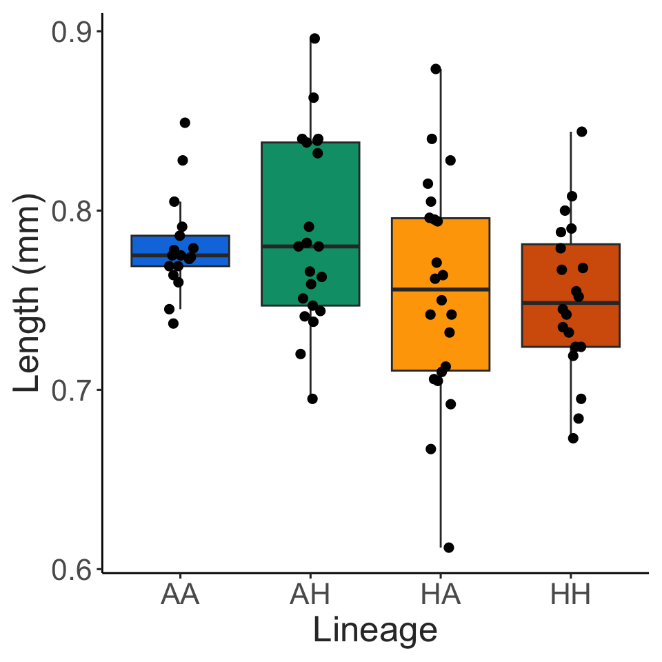

```r
ggplot(full_data, aes(x = lineage, y = length, fill = lineage)) +
  geom_boxplot(outlier.colour = NA) +
  geom_point(size = 2, position = position_jitter(width = 0.1, height = 0)) +
  scale_fill_manual(values = lineage_cols) +
  labs(x = "Lineage",
       y = "Length (mm)") +
  theme_matt(base_size = 16) +
  theme(legend.position = "none")
```

After the small individual is excluded, there is no significant difference in size across the lineages. To test this, we fit a linear mixed effects model to the data (length ~ lineage, with a random effect of replicate culture). Note, here and in the other models replicate culture ID has been re-coded from 1-4, to a unique identifier (AA_1, AA_2, AA_3, AA_4, etc.).

```r
use_data = full_data %>%
  filter(ctmax > 33 & length > 0.72) %>%
  mutate(id = paste(lineage, replicate, sep = "_"))

length.model = nlme::lme(length ~ lineage,
                        random = ~1|id,
                        data = use_data)

kable(car::Anova(length.model))
```

|  | Chisq | Df | Pr(>Chisq) |
| --- | --- | --- | --- |
| lineage | 2.005465 | 3 | 0.5712733 |

## CTmax

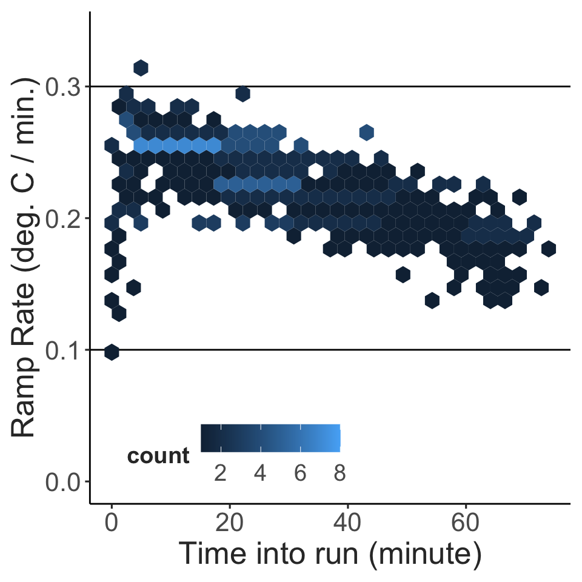

```r
ramp_record2 = ramp_record %>%
  group_by(run, minute_interval) %>%
  summarise(mean_ramp = mean(ramp_per_minute)) %>%
  drop_na(minute_interval, mean_ramp)

ggplot(ramp_record2, aes(x = minute_interval, y = mean_ramp)) +
  geom_hline(yintercept = 0.3) +
  geom_hline(yintercept = 0.1) +
  geom_hex(bins = 30) +
  ylim(0,0.34) +
  labs(y = "Ramp Rate (deg. C / min.)",
       x = "Time into run (minute)") +
  theme_matt(base_size = 16) +
  theme(legend.position = c(0.3, 0.1),
        legend.direction = "horizontal")
```

```r
kable(full_data %>%
        filter(ctmax < 33 | length < 0.65) %>%
        count(lineage),
      caption = "Number of individual measurements excluded from each of the lineages")
```

Number of individual measurements excluded from each of the lineages

| lineage | n |
| --- | --- |
| AA | 1 |
| AH | 3 |
| HA | 3 |

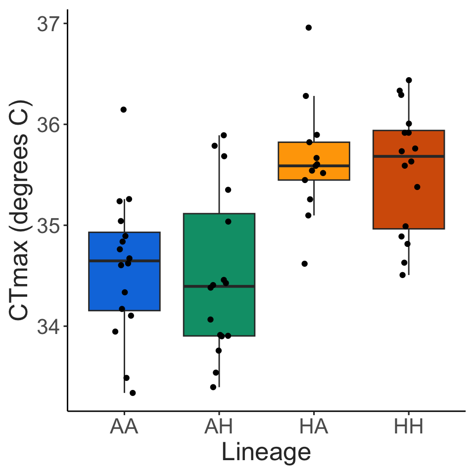

```r
ggplot(use_data, aes(x = lineage, y = ctmax, fill = lineage)) +
  geom_boxplot(outlier.colour = NA) +
  geom_point(position = position_jitter(width = 0.1, height = 0)) +
  scale_fill_manual(values = lineage_cols) +
  labs(x = "Lineage",
       y = "CTmax (degrees C)") +
  theme_matt(base_size = 16) +
  theme(legend.position = "none")
```

To test for differences between lineages, we fit a linear mixed effects model to the data (CTmax ~ lineage + length, with a random effect of replicate culture). This model indicates significant difference between lineages, as well as a significant effect of length.

```r
ctmax.model = nlme::lme(fixed = ctmax ~ lineage + length,
                        random = ~1|id,
                        data = use_data)

kable(car::Anova(ctmax.model))
```

|  | Chisq | Df | Pr(>Chisq) |
| --- | --- | --- | --- |
| lineage | 34.369251 | 3 | 0.0000002 |
| length | 5.090427 | 1 | 0.0240583 |

```r
#model_resid = resid(ctmax.model, type = 'pearson')
#qqnorm(model_resid); qqline(model_resid, col = 2)
```

A posthoc test confirms that differences occur between the temperature groups, but not between the CO2 groups - that is, copepods from the high temperature lineages have higher CTmax values, regardless of the CO2 concentration.

```r
kable(emmeans::emmeans(ctmax.model, pairwise~lineage)$contrasts)
```

| contrast | estimate | SE | df | t.ratio | p.value |
| --- | --- | --- | --- | --- | --- |
| AA - AH | 0.0632684 | 0.2386491 | 12 | 0.2651105 | 0.9931279 |
| AA - HA | -1.0886621 | 0.2516969 | 12 | -4.3252908 | 0.0047139 |
| AA - HH | -0.8739237 | 0.2409285 | 12 | -3.6273155 | 0.0158352 |
| AH - HA | -1.1519305 | 0.2507917 | 12 | -4.5931759 | 0.0029901 |
| AH - HH | -0.9371920 | 0.2439369 | 12 | -3.8419449 | 0.0108787 |
| HA - HH | 0.2147384 | 0.2572273 | 12 | 0.8348196 | 0.8370223 |

We also examined whether the individual environmental factors (temperature or CO2 levels) affected CTmax. Here again we show that culturing temperature appears to have a significant effect on CTmax, while CO2 level does not. Further, there is no interaction between the two factors, suggesting that CO2 level does not alter the effect that temperature has on CTmax.

```r
env.model = nlme::lme(fixed = ctmax ~ temp * co2,
                        random = ~1|id,
                        data = use_data)

kable(car::Anova(env.model, type = "III"))
```

|  | Chisq | Df | Pr(>Chisq) |
| --- | --- | --- | --- |
| (Intercept) | 3.029277e+04 | 1 | 0.0000000 |
| temp | 1.198340e+01 | 1 | 0.0005368 |
| co2 | 2.183734e-01 | 1 | 0.6402821 |
| temp:co2 | 1.090000e-02 | 1 | 0.9168495 |

```r
#env.model_resid = resid(env.model, type = 'pearson')
#qqnorm(env.model_resid); qqline(env.model_resid, col = 2)
```

# Estimation Plots

Another approach we could use is to measure effect sizes, which can be visualized using estimation plots. The disadvantage here is that different replicates within lineages are not taken into account. However, in this form, the observed differences between temperature groups (rather than CO2 groups) is clear - lineages that develop at high temperatures have higher thermal limits, regardless of the CO2 level.

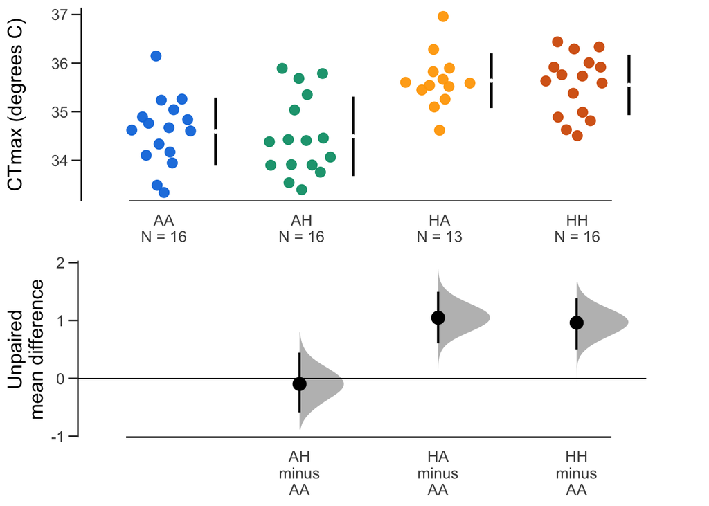

```r
ctmax_eff_sizes = use_data %>%
  dabest(lineage, ctmax,
         idx = c("AA", "AH", "HA", "HH"),
         paired = FALSE
         )

ctmax_mean_diff = ctmax_eff_sizes %>% mean_diff()
cohens = eff_sizes %>% cohens_d()

plot(ctmax_mean_diff,
     rawplot.markersize = 3,
     palette = lineage_cols,
     rawplot.ylabel = "CTmax (degrees C)")
```

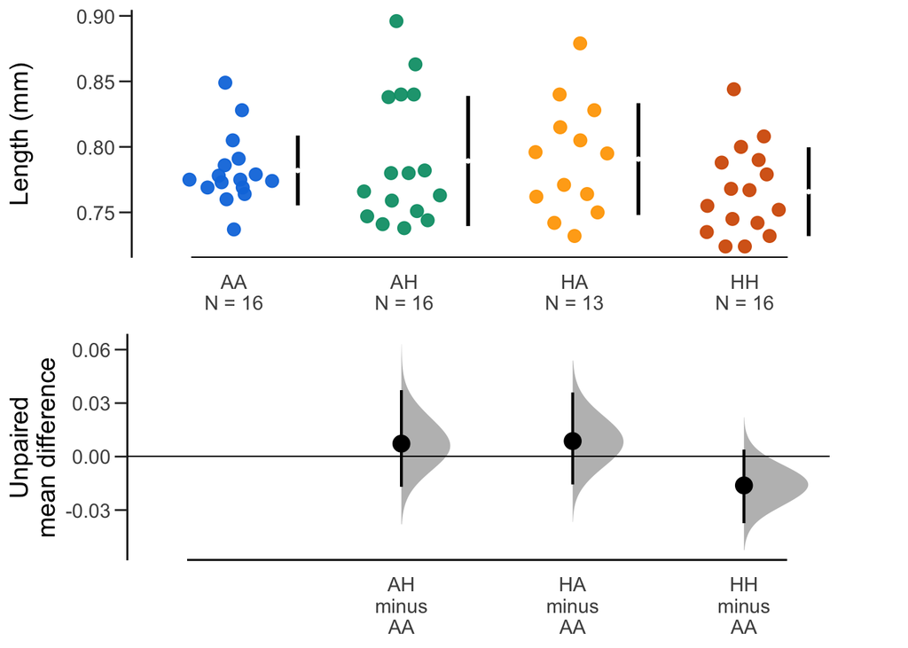

```r
size_eff_sizes = use_data %>%
  dabest(lineage, length,
         idx = c("AA", "AH", "HA", "HH"),
         paired = FALSE
         )

length_mean_diff = size_eff_sizes %>% mean_diff()

plot(length_mean_diff,
     rawplot.markersize = 3,
     palette = lineage_cols,
     rawplot.ylabel = "Length (mm)")
```

# Trait correlations

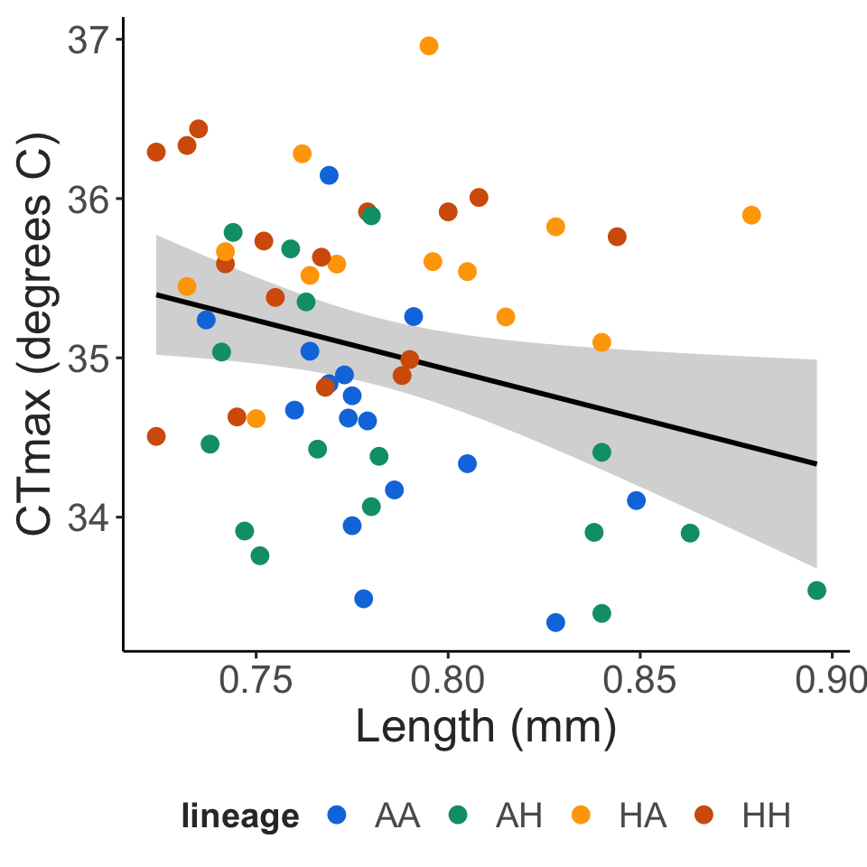

```r
full_data %>%
  filter(ctmax > 33 & length > 0.72) %>%
  ggplot(aes(x = length, y = ctmax)) +
  geom_smooth(method = "lm", colour = "black") +
  geom_point(size = 3, aes(colour = lineage)) +
  scale_colour_manual(values = lineage_cols) +
  labs(x = "Length (mm)",
       y = "CTmax (degrees C)") +
  theme_matt(base_size = 16) +
  theme(legend.position = "bottom")
```